# Lab 6: July 20

POLS 3316, Summer 2022, University of Houston, Instructor: Tom Hanna

##Probabilities with R frequency distribution functions

In this lab, we use the distribution functions from R for calculating probabilities.

1. Create a variable x with values (-2,-1,0,1,2)

```r
x <- c(-2,-1,0,1,2)
```

2. What is the probability of getting a value less than a given value (to the left of that value in the distribution) in a normal distribution with mean 0 and standard deviation 1?

*mean = 0, standard deviation = 1 is the default for the normal distribution functions in R*

First, let’s look graphically at what that means:

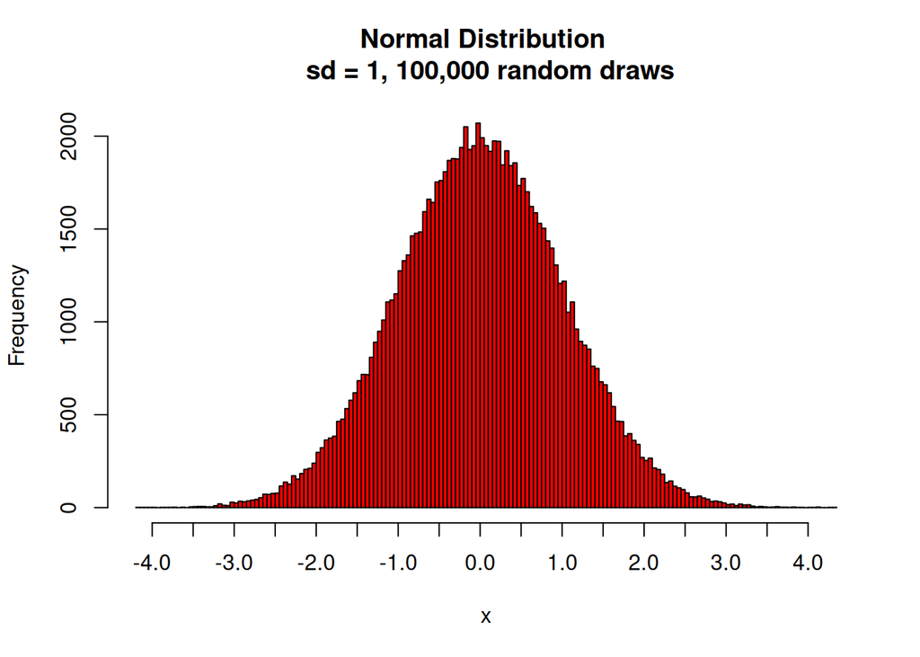

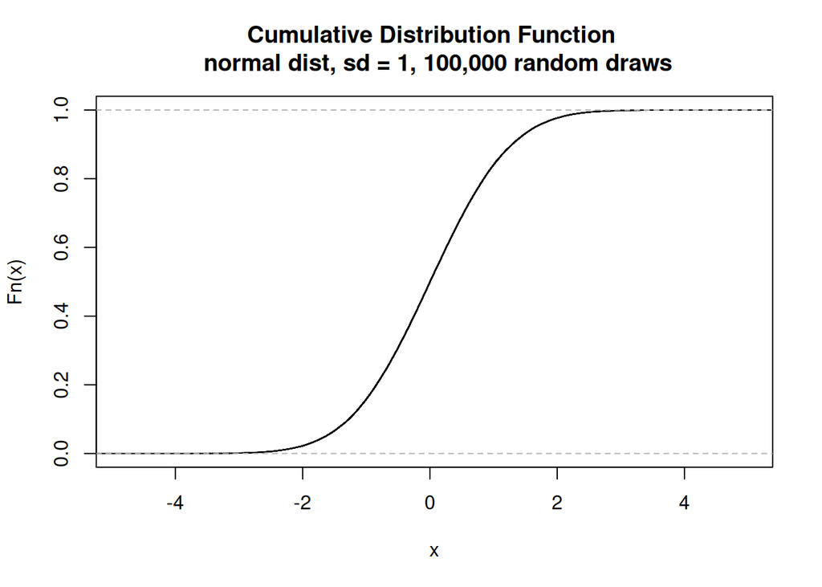

**What would we expect with each of those values?**

```r
#pnorm gives the probability to the left of (x)
pnorm(-2)
```

```
## [1] 0.02275013
```

3. Create a vector that contains the probabilities for all values of x and return the vector.

```r
pnorm_x <- pnorm(x)
pnorm_x
```

```
## [1] 0.02275013 0.15865525 0.50000000 0.84134475 0.97724987
```

4. Now create a variable “y” with values: (0,1,2,5,8,10,15,20)

```r
y <- c(0,1,2,5,8,10,15,20)
```

5. Using a binomial distribution, calculate the value of the cumulative distribution function at a given value of y. Example: 0

```r
pbinom(0,size=20,prob=.2)
```

```
## [1] 0.01152922
```

6. Now create a vector with the binomial probabilities of all y values.

```r
pbin_y <- pbinom(y,size=20,prob=.2)
```

7. Repeat Question 6 but using the Poisson and Uniform Distributions - commands are *ppois()* and *puni* - create vectors named vector_y_pois and vector_y_uni

## Calculating probabilities with the functions:

8. Probability that a normal random variable with mean 22 and variance 25 lies between 16.2 and 27.5.

```r
#First, we need the standard deviation
sqrt(25)
```

```
## [1] 5
```

```r
#we use the pnorm function - the probability distribution function #for the normal distribution
#The first argument is the vector (or scalar) we want to compute
#The second argument is the mean of the distribution (22)
#The third argument is the standard deviation
# First, I am going to compute the values at each point and assign to vectors
point_1 <- pnorm(27.5,22,sd=5)
point_2 <- pnorm(16.2,22,sd=5)

#We subtract one result from the other
answer8 <- point_1 - point_2
answer8
```

```
## [1] 0.7413095
```

```r
#It is possible to just subtract one function from the other
answer_8a <- pnorm(27.5,22,sd=5) - pnorm(16.2,22,sd=5)
answer_8a
```

```
## [1] 0.7413095
```

9. Probability that a normal random variable with mean 22 and variance 25 is greater than 29

```r
#We use the same function for a value of 29
#and subtract from 1

1 - pnorm(29,22,sd=5)
```

```
## [1] 0.08075666
```

10. If we wanted to know the probability for **less than** 17 instead of greater than:

```r
pnorm(17,22,sd=5)
```

```
## [1] 0.1586553
```

11. And if we wanted to know the probability that it was less than 15 or greater than 25 (mutually exclusive possibilities):

```r
#The parentheses around the two parts aren't strictly necessary
#I just wanted to separate the two probabilities
(pnorm(15,22,sd=5)) +  (1-pnorm(25,22,sd=5))
```

```
## [1] 0.3550098
```